# KNN

Mukandi Herzel Shingirirai

2025-04-22

## K Nearest Neighbours (kNN)

### **What is K-Nearest Neighbors (KNN)?**

K-Nearest Neighbors (KNN) is a simple, intuitive machine learning algorithm used for both **classification** and **regression**. It works by predicting the output based on the **K nearest data points** to the input point.

### **How does KNN work?**

1. **Choose the number of neighbors (K)**:
   - We begin by choosing the number **K**. This represents the number of neighbors we will look at when making a prediction. A typical value for **K** is 3, 5, or 7.
2. **Measure the distance**:
   - The next step is to measure the **distance** between the data points. **Euclidean distance** is commonly used, but other distance metrics are also possible.
3. **Find the nearest neighbors**:
   - After calculating the distance, we identify the **K nearest neighbors** to the data point.
4. **Make the prediction**:
   - **For classification**: The point is assigned the most common class among its **K nearest neighbors**.
   - **For regression**: The prediction is made by averaging the values of the K nearest neighbors.

### Import Packages

First we import the relevant packages:

```python
import numpy as np
import pandas as pd
import matplotlib.pyplot as plt
import seaborn as sns
from sklearn.preprocessing import StandardScaler
from imblearn.over_sampling import RandomOverSampler
import warnings
warnings.filterwarnings('ignore')
```

### Load and Explore the dataset

We then load and explore the dataset.

```python
# Create a list of columns to add them as column names, since the dataset does not have column names
cols = ['fLength', 'fWidth', 'fSize', 'fConc', 'fConc1', 'fAsym', 'fM3Long', 'fM3Trans', 'fAlpha', 'fDist', 'class']
df = pd.read_csv('data/magic04.data', names=cols)
df.head()
```

```
##     fLength    fWidth   fSize   fConc  ...  fM3Trans   fAlpha     fDist  class
## 0   28.7967   16.0021  2.6449  0.3918  ...   -8.2027  40.0920   81.8828      g
## 1   31.6036   11.7235  2.5185  0.5303  ...   -9.9574   6.3609  205.2610      g
## 2  162.0520  136.0310  4.0612  0.0374  ...  -45.2160  76.9600  256.7880      g
## 3   23.8172    9.5728  2.3385  0.6147  ...   -7.1513  10.4490  116.7370      g
## 4   75.1362   30.9205  3.1611  0.3168  ...   21.8393   4.6480  356.4620      g
##
## [5 rows x 11 columns]
```

Checking the class:

```python
# Check the class
df["class"].unique()
```

```
## array(['g', 'h'], dtype=object)
```

Converting the class from string to int.

```python
# Lets convert "class" to numeric
df["class"] = (df["class"] == "g").astype(int)
```

Confirming the conversion:

```python
# Now let us recheck "class"
df["class"].unique()
```

```
## array([1, 0])
```

```python
df.head()
```

```
##     fLength    fWidth   fSize   fConc  ...  fM3Trans   fAlpha     fDist  class
## 0   28.7967   16.0021  2.6449  0.3918  ...   -8.2027  40.0920   81.8828      1
## 1   31.6036   11.7235  2.5185  0.5303  ...   -9.9574   6.3609  205.2610      1
## 2  162.0520  136.0310  4.0612  0.0374  ...  -45.2160  76.9600  256.7880      1
## 3   23.8172    9.5728  2.3385  0.6147  ...   -7.1513  10.4490  116.7370      1
## 4   75.1362   30.9205  3.1611  0.3168  ...   21.8393   4.6480  356.4620      1
##
## [5 rows x 11 columns]
```

### Ploting the various features to get a look at how they are distributed

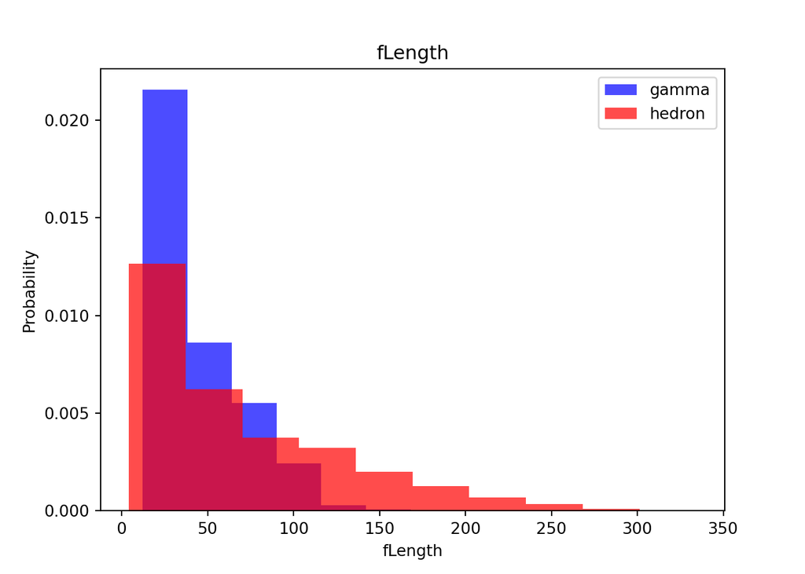

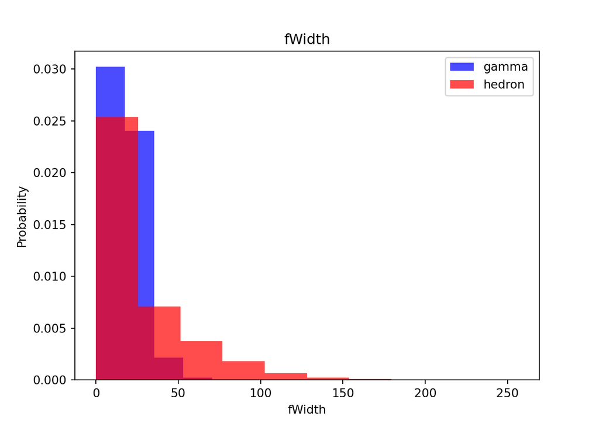

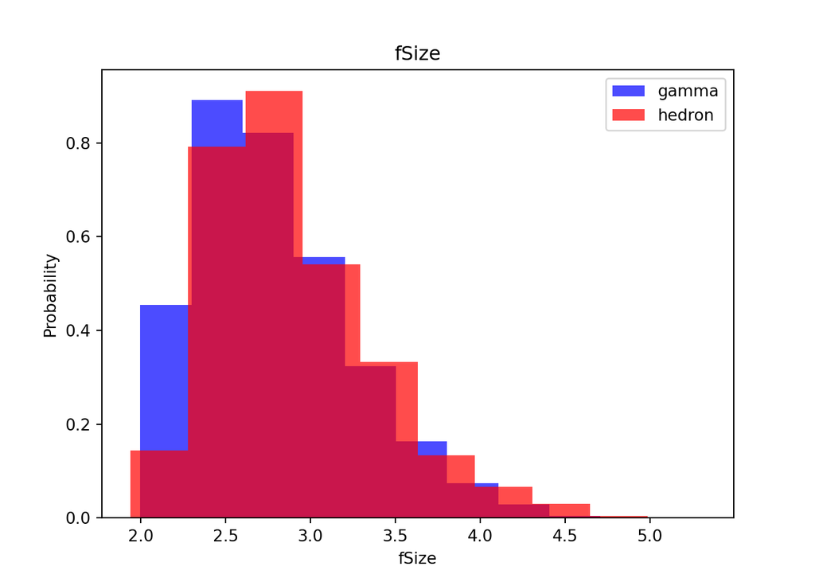

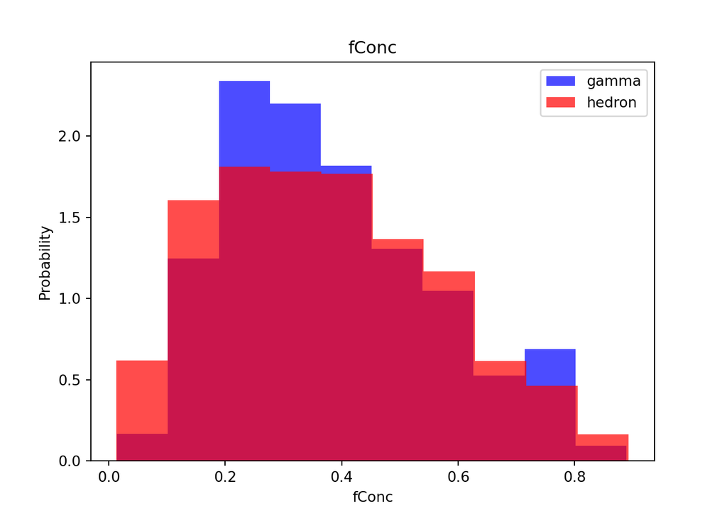

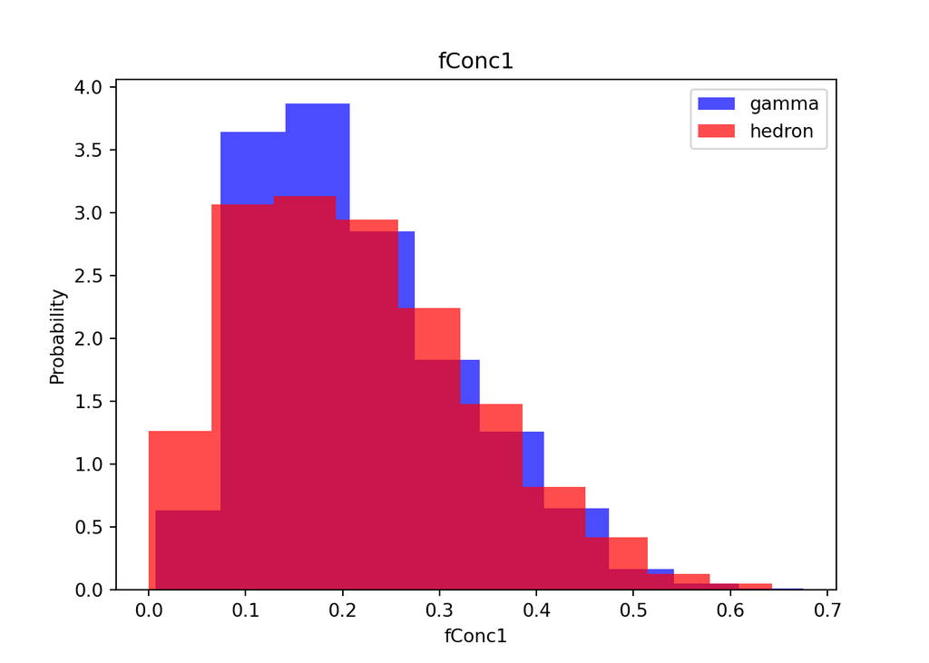

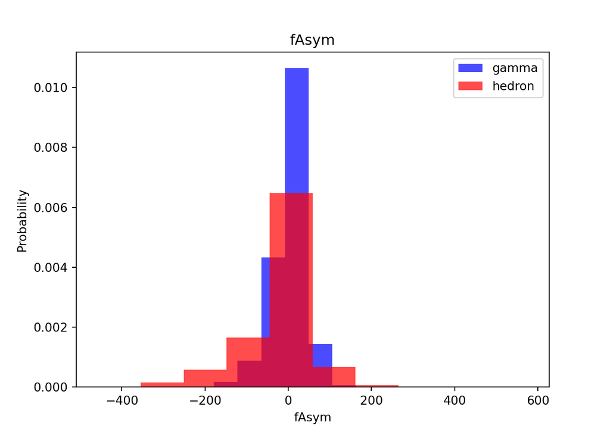

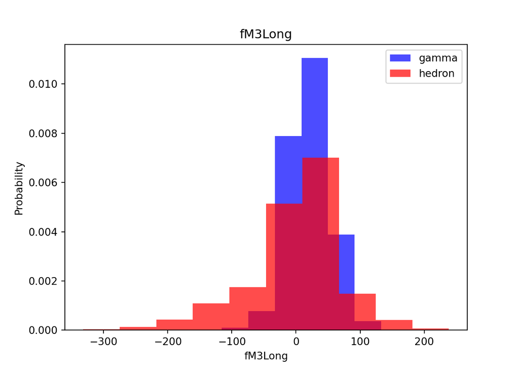

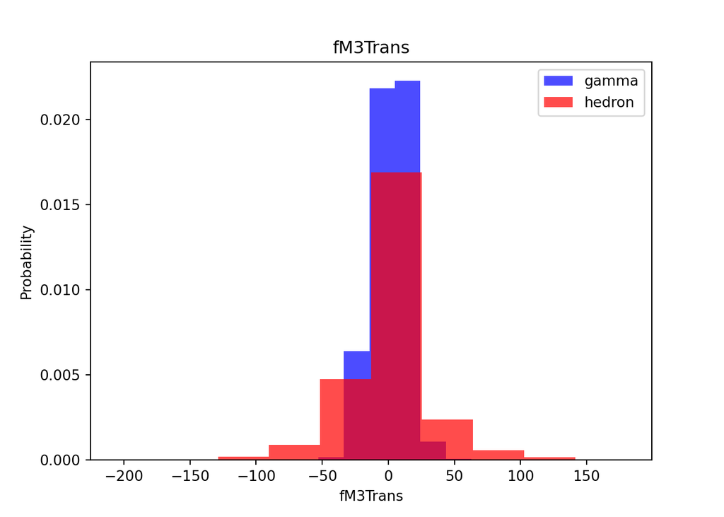

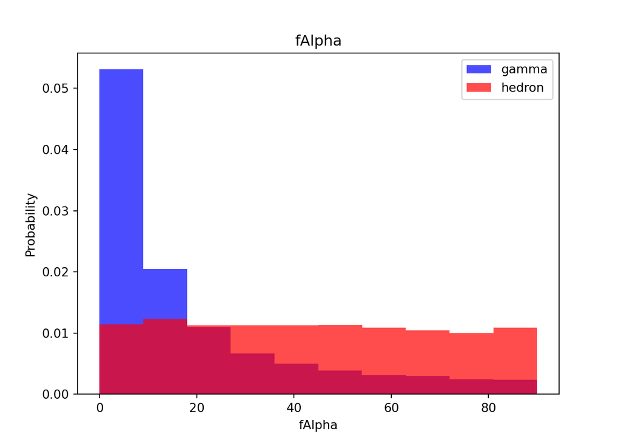

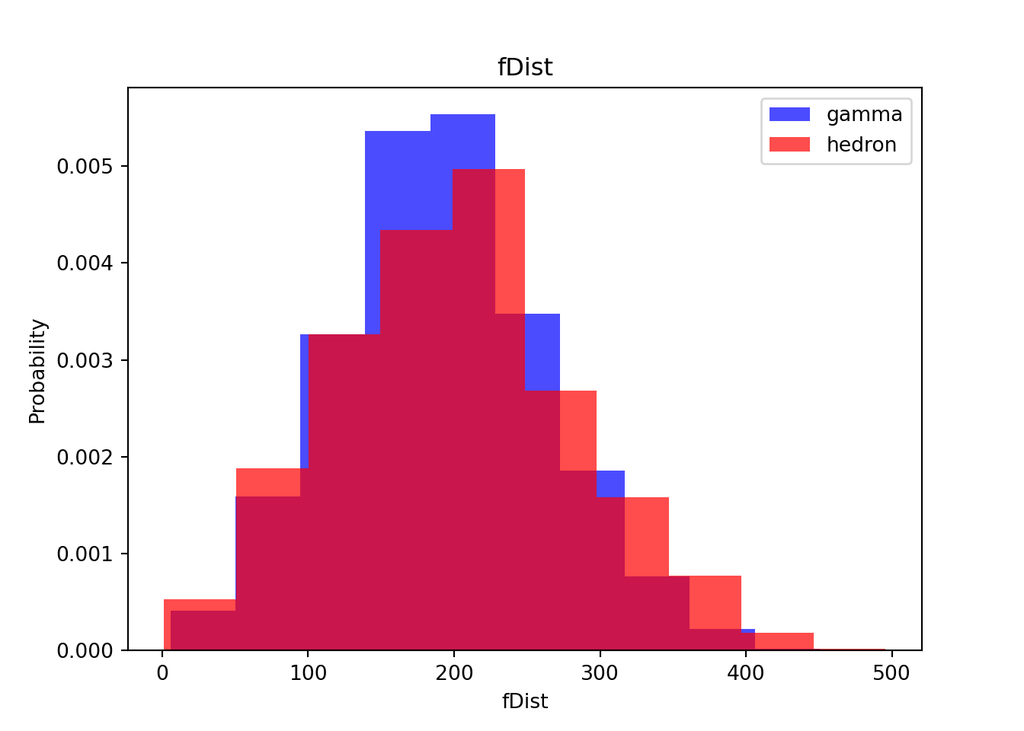

```python
for label in cols[:-1]:
  plt.hist(df[df["class"] == 1][label], color="blue", label="gamma", alpha=0.7, density=True)
  plt.hist(df[df["class"] == 0][label], color="red", label="hedron", alpha=0.7, density=True)
  plt.title(label)
  plt.ylabel("Probability")
  plt.xlabel(label)
  plt.legend()
  plt.show()
```

## Preparing the Train, Validation and Test Datasets

```python
train, valid, test = np.split(df.sample(frac=1), [int(0.6*len(df)), int(0.8*len(df))])
```

```python
def scale_dataset(dataframe, oversample=False):
  x = dataframe[dataframe.columns[:-1]].values
  y = dataframe[dataframe.columns[-1]].values

  scaler = StandardScaler()
  x = scaler.fit_transform(x)

  if oversample:
    x, y = RandomOverSampler().fit_resample(x, y)

  # Create the whole data as a horizontal numpy array
  data = np.hstack((x, np.reshape(y, (-1, 1))))

  return data, x, y
```

### Checking the length

```python
print(len(train[train["class"] == 1])) # Gamma
```

```
## 7390
```

```python
print(len(train[train["class"] == 0])) # Hadron
```

```
## 4022
```

We want to over-sample our data so that these match.

```python
train, x_train, y_train = scale_dataset(train, oversample=True)
valid, x_valid, y_valid = scale_dataset(valid, oversample=False)
test, x_test, y_test = scale_dataset(test, oversample=False)
```

```python
from sklearn.neighbors import KNeighborsClassifier
from sklearn.metrics import classification_report
```

```python
knn_model = KNeighborsClassifier(n_neighbors = 5)
knn_model.fit(x_train, y_train)
```

```
KNeighborsClassifier()
```

```python
y_pred = knn_model.predict(x_test)
```

```python
print(classification_report(y_test, y_pred))
```

```
##               precision    recall  f1-score   support
##
##            0       0.74      0.73      0.73      1349
##            1       0.85      0.86      0.85      2455
##
##     accuracy                           0.81      3804
##    macro avg       0.79      0.79      0.79      3804
## weighted avg       0.81      0.81      0.81      3804
```

### Exploring what we mean by Precison, Recal and Accuracy

Precision:

$$\text{Prescision} = \frac{\text{True positives}}{\text{True Positives} +
\text{False Positives}}$$

Recall

$$\text{Recall} = \frac{\text{True Postives}}{\text{False Negatives} +
\text{True Positives}}$$